# IS 470 Lab 1: Introduction to Colab

# Part 1: Google Colab

Google Colab is an executable document that allows you to write and execute Python in your browser. Colab connects your notebook to a cloud based runtime provided by Google.

- Notebook documents stored in Google Drive
- A notebook document is a list of cells

## 1. Cells

Colab has two types of cells: text and code. Click a cell to select it.

### 1.1 Text cells

Text cells are formatted using a simple markup language called Markdown. Double-click to edit a text cell.  
Headings are rendered as titles.

- "# Section 1"
- "# Section 2"
- "## Sub-section under Section 2"
- "### Sub-section under the sub-section under Section 2"

The **table of contents**, available on the left side of Colab, can be used to navigate through the document.

### 1.2 Code cells

Below is a code cell. You can click in the cell to select it and execute the Python codes in the following ways:

- Click the **Play icon** in the left gutter of the cell;
- Type **Cmd/Ctrl+Enter** to run the cell in place;

```python
print("IS470 lab1")
```

[output not shown]

### 1.3 Adding, moving, and deleting cells

You can add new cells by using the **+ CODE** and **+ TEXT** buttons that show when you hover between cells. These buttons are also in the toolbar above the notebook where they can be used to add a cell below the currently selected cell.

You can move a cell by selecting it and clicking **Cell Up** or **Cell Down** in the toolbar.

You can delete a cell by selecting it and clicking on the **Delete cell** button on the top-right corner of the cell.

## 2. Save your notebook document

- File -> Save
- Type **Cmd/Ctrl+S**

## 3. Download your notebook document

- File -> Download -> Download .ipynb
- Download the file from Google Drive

# Part 2: Basic operators and data structures in Python

```python
# Mounting Google Drive
from google.colab import drive
drive.mount('/content/drive')
```

```python
# Import libraries
import pandas as pd
import seaborn as sns
```

```python
# Read data (with assignment operator)
pokemon = pd.read_csv('/content/drive/MyDrive/IS470_data/pokemon.csv')
# pokemon is a dataframe
pokemon
```

|  | # | Name | Type 1 | Type 2 | HP | Attack | Defense | Sp. Atk | Sp. Def | Speed | Generation | Legendary |
| --- | --- | --- | --- | --- | --- | --- | --- | --- | --- | --- | --- | --- |
| 0 | 1 | Bulbasaur | Grass | Poison | 45 | 49 | 49 | 65 | 65 | 45 | 1 | False |
| 1 | 2 | Ivysaur | Grass | Poison | 60 | 62 | 63 | 80 | 80 | 60 | 1 | False |
| 2 | 3 | Venusaur | Grass | Poison | 80 | 82 | 83 | 100 | 100 | 80 | 1 | False |
| 3 | 4 | Mega Venusaur | Grass | Poison | 80 | 100 | 123 | 122 | 120 | 80 | 1 | False |
| 4 | 5 | Charmander | Fire | NaN | 39 | 52 | 43 | 60 | 50 | 65 | 1 | False |
| ... | ... | ... | ... | ... | ... | ... | ... | ... | ... | ... | ... | ... |
| 795 | 796 | Diancie | Rock | Fairy | 50 | 100 | 150 | 100 | 150 | 50 | 6 | True |
| 796 | 797 | Mega Diancie | Rock | Fairy | 50 | 160 | 110 | 160 | 110 | 110 | 6 | True |
| 797 | 798 | Hoopa Confined | Psychic | Ghost | 80 | 110 | 60 | 150 | 130 | 70 | 6 | True |
| 798 | 799 | Hoopa Unbound | Psychic | Dark | 80 | 160 | 60 | 170 | 130 | 80 | 6 | True |
| 799 | 800 | Volcanion | Fire | Water | 80 | 110 | 120 | 130 | 90 | 70 | 6 | True |

800 rows × 12 columns

```python
# Examine the number of rows and cols
pokemon.shape
```

```
(800, 12)
```

```python
# Show the head rows of a data frame
pokemon.head()
```

|  | # | Name | Type 1 | Type 2 | HP | Attack | Defense | Sp. Atk | Sp. Def | Speed | Generation | Legendary |
| --- | --- | --- | --- | --- | --- | --- | --- | --- | --- | --- | --- | --- |
| 0 | 1 | Bulbasaur | Grass | Poison | 45 | 49 | 49 | 65 | 65 | 45 | 1 | False |
| 1 | 2 | Ivysaur | Grass | Poison | 60 | 62 | 63 | 80 | 80 | 60 | 1 | False |
| 2 | 3 | Venusaur | Grass | Poison | 80 | 82 | 83 | 100 | 100 | 80 | 1 | False |
| 3 | 4 | Mega Venusaur | Grass | Poison | 80 | 100 | 123 | 122 | 120 | 80 | 1 | False |
| 4 | 5 | Charmander | Fire | NaN | 39 | 52 | 43 | 60 | 50 | 65 | 1 | False |

```python
# Obtain the Attack value for every pokemon
pokemon[[ 'Attack' ]]
```

|  | Attack |
| --- | --- |
| 0 | 49 |
| 1 | 62 |
| 2 | 82 |
| 3 | 100 |
| 4 | 52 |
| ... | ... |
| 795 | 100 |
| 796 | 160 |
| 797 | 110 |
| 798 | 160 |
| 799 | 110 |

800 rows × 1 columns

```python
# Obtain the Attack and Defense values for every pokemon
pokemon[['Attack', 'Defense']]
```

|  | Attack | Defense |
| --- | --- | --- |
| 0 | 49 | 49 |
| 1 | 62 | 63 |
| 2 | 82 | 83 |
| 3 | 100 | 123 |
| 4 | 52 | 43 |
| ... | ... | ... |
| 795 | 100 | 150 |
| 796 | 160 | 110 |
| 797 | 110 | 60 |
| 798 | 160 | 60 |
| 799 | 110 | 120 |

800 rows × 2 columns

```python
# Extract the first row from data frame
pokemon.iloc[0,:]
```

```
#                     1
Name          Bulbasaur
Type 1            Grass
Type 2           Poison
HP                   45
Attack               49
Defense              49
Sp. Atk              65
Sp. Def              65
Speed                45
Generation            1
Legendary         False
Name: 0, dtype: object
```

```python
# Extract the last row from data frame
pokemon.iloc[-1,:]
```

```
#                   800
Name          Volcanion
Type 1             Fire
Type 2            Water
HP                   80
Attack              110
Defense             120
Sp. Atk             130
Sp. Def              90
Speed                70
Generation            6
Legendary          True
Name: 799, dtype: object
```

```python
# Extract the third column from data frame
pokemon.iloc[:,2]
```

```
0        Grass
1        Grass
2        Grass
3        Grass
4         Fire
        ...
795       Rock
796       Rock
797    Psychic
798    Psychic
799       Fire
Name: Type 1, Length: 800, dtype: object
```

```python
# Extract the last column from data frame
pokemon.iloc[:,-1]
```

```
0      False
1      False
2      False
3      False
4      False
       ...
795     True
796     True
797     True
798     True
799     True
Name: Legendary, Length: 800, dtype: bool
```

```python
# Extract the first three columns from the data frame
pokemon.iloc[:,0:3]
```

|  | # | Name | Type 1 |
| --- | --- | --- | --- |
| 0 | 1 | Bulbasaur | Grass |
| 1 | 2 | Ivysaur | Grass |
| 2 | 3 | Venusaur | Grass |
| 3 | 4 | Mega Venusaur | Grass |
| 4 | 5 | Charmander | Fire |
| ... | ... | ... | ... |
| 795 | 796 | Diancie | Rock |
| 796 | 797 | Mega Diancie | Rock |
| 797 | 798 | Hoopa Confined | Psychic |
| 798 | 799 | Hoopa Unbound | Psychic |
| 799 | 800 | Volcanion | Fire |

800 rows × 3 columns

```python
# Extract the value in the first row and fifth column of the data frame
pokemon.iloc[0,4]
```

```
45
```

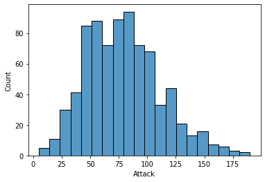

```python
# Histogram of Attack
snsplot = sns.histplot(x= 'Attack' , data = pokemon)
```

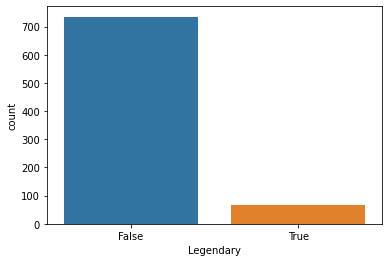

```python
# Plot a categorical variable: Legendary
snsplot = sns.countplot(x = 'Legendary' , data = pokemon)
```

```python
!jupyter nbconvert --to html "/content/drive/MyDrive/IS470_lab/IS470_lab1.ipynb"
```